# Day four - 7/13

Marcus W. Beck, beck.marcus@epa.gov

### Editing metadata in R

Use `library(EML)`

```r
library(EML)
# library(arcticdatautils) # eml_creator

doc <- read_eml('strix-pacific-northwest.xml')
doc
```

```
## <eml packageId="urn:uuid:439c8d9d-f0ed-4f47-8cac-275d0d64bafd" system="uuid" xsi:schemaLocation="eml://ecoinformatics.org/eml-2.1.1 eml.xsd">
##   <dataset scope="document">
##     <title>Strix occidentalis Distribution in the Pacific Northwest.</title>
##     <creator>
##       <individualName>
##         <givenName>Connell</givenName>
##         <surName>Joseph</surName>
##       </individualName>
##       <electronicMailAddress>jconnell@example.com</electronicMailAddress>
##     </creator>
##     <pubDate>2015-12-14</pubDate>
##     <abstract>Strix occidentalis sightings in the Pacific Northwest.</abstract>
##     <intellectualRights>CC0, http://creativecommons.org/publicdomain/zero/1.0</intellectualRights>
##     <coverage>
##       <geographicCoverage>
##         <geographicDescription>Northwest Oregon</geographicDescription>
##         <boundingCoordinates>
##           <westBoundingCoordinate>-124.07</westBoundingCoordinate>
##           <eastBoundingCoordinate>-123.22</eastBoundingCoordinate>
##           <northBoundingCoordinate>45.53</northBoundingCoordinate>
##           <southBoundingCoordinate>44.47</southBoundingCoordinate>
##         </boundingCoordinates>
##       </geographicCoverage>
##       <temporalCoverage>
##         <rangeOfDates>
##           <beginDate>
##             <calendarDate>2015</calendarDate>
##           </beginDate>
##           <endDate>
##             <calendarDate>2015</calendarDate>
##           </endDate>
##         </rangeOfDates>
##       </temporalCoverage>
##     </coverage>
##     <contact>
##       <individualName>
##         <givenName>Connell</givenName>
##         <surName>Joseph</surName>
##       </individualName>
##       <electronicMailAddress>jconnell@example.com</electronicMailAddress>
```

[output cut: 69 more lines]

```
##         <dataFormat>
##           <externallyDefinedFormat>
##             <formatName>text/csv</formatName>
##           </externallyDefinedFormat>
##         </dataFormat>
##         <distribution id="1430343425154">
##           <online>
##             <url function="download"/>
##           </online>
##         </distribution>
##       </physical>
##       <entityType>Other</entityType>
##     </otherEntity>
##   </dataset>
## </eml>
```

Edit the creator field:

```r
doc@dataset@creator
doc@dataset@creator <- c(eml_creator('Turbo', 'Todd'), email = 'turbotodd@rad.com')
```

Edit the abstract, write file.

```r
# Change abstract to the better one we wrote
doc@dataset@abstract <- as(set_TextType("better-abstract.md"), "abstract")

# Save it back to the filesystem
write_eml(doc, "strix-pacific-northwest.xml")
```

### Publishing data (on DataONE)

Published as a data package which is one or more datasets and a metadata file.

An example:

```r
library(dataone)
library(datapack)
library(uuid)

# create an empty package
dp <- new("DataPackage")
dp
```

```
## This package does not contain any DataObjects:
##
## This package doesn not contain any provenance relationships.
```

We then add a metadata file:

```r
emlFile <- "strix-pacific-northwest.xml"
metadataObj <- new("DataObject", format="eml://ecoinformatics.org/eml-2.1.1", filename=paste(getwd(), emlFile, sep="/"),
                   suggestedFilename=basename(emlFile))
dp <- addData(dp, metadataObj)
```

We then add data:

```r
sourceData <- "sample.csv"
sourceObj <- new("DataObject", format="text/csv", filename=paste(getwd(), sourceData, sep="/"), suggestedFilename=basename(sourceData))
dp <- addData(dp, sourceObj, metadataObj)
```

Then maybe add some script for processing the data:

```r
progFile <- "filterSpecies.R"
progObj <- new("DataObject", format="application/R", filename=paste(getwd(), progFile, sep="/"), mediaType="text/x-rsrc",
                suggestedFilename=basename(progFile))
dp <- addData(dp, progObj, metadataObj)
```

Then the processed data file is added:

```r
outputData <- "filteredSpecies.csv"
outputObj <- new("DataObject", format="text/csv", filename=paste(getwd(), outputData, sep="/"), suggestedFilename=basename(outputData))
dp <- addData(dp, outputObj, metadataObj)

myAccessRules <- data.frame(subject="http://orcid.org/0000-0003-0077-4738", permission="changePermission")

dp
```

Finally, we upload the package to the Testing server for the KNB.

```r
d1c <- D1Client("STAGING2", "urn:node:mnTestKNB")
packageId <- uploadDataPackage(d1c, dp, public=TRUE, accessRules=myAccessRules, quiet=FALSE)
```

This particular package contains the R script `filterSpecies.R`, the input file `sample.csv` that was read by the script and the output file `filteredSpecies.csv` that was created by the R script, which was run at a previous time.

You can now search for and view the package at https://dev.nceas.ucsb.edu

**Make DataONE profile to doc and upload data!!**

### Open data in R

Go here to check out list of open data sources that can be dled from within R:

https://github.com/ropensci/opendata

Examples:

`rplos`: R client for the PLoS Journals API

- Package: https://github.com/ropensci/rplos
- Website: http://api.plos.org/

```r
library(rplos)
searchplos(q='everything:"gulf of mexico"', fl='title', fq='doc_type:full', limit=10)
```

```
## $meta
##   numFound start maxScore
## 1     1048     0       NA
##
## $data
##                                                                                                                                                                             title
## 1                                                                         Correction: Fish Sound Production in the Presence of Harmful Algal Blooms in the Eastern Gulf of Mexico
## 2  Correction: Trophic Ecology of Atlantic Bluefin Tuna (Thunnusthynnus) Larvae from the Gulf of Mexico and NW Mediterranean Spawning Grounds: A Comparative Stable Isotope Study
## 3                             Correction: Horizontal Movements, Migration Patterns, and Population Structure of Whale Sharks in the Gulf of Mexico and Northwestern Caribbean Sea
## 4                                                                            Words Analysis of Online Chinese News Headlines about Trending Events: A Complex Network Perspective
## 5              Trophic Ecology of Atlantic Bluefin Tuna (Thunnusthynnus) Larvae from the Gulf of Mexico and NW Mediterranean Spawning Grounds: A Comparative Stable Isotope Study
## 6                                                               First Autonomous Bio-Optical Profiling Float in the Gulf of Mexico Reveals Dynamic Biogeochemistry in Deep Waters
## 7                                 Genetic Connectivity in Scleractinian Corals across the Northern Gulf of Mexico: Oil/Gas Platforms, and Relationship to the Flower Garden Banks
## 8                                                                                        Atlantic Bluefin Tuna: A Novel Multistock Spatial Model for Assessing Population Biomass
## 9                                                                                      Potential Connectivity of Coldwater Black Coral Communities in the Northern Gulf of Mexico
## 10                      Temporal and spatial comparisons of the reproductive biology of northern Gulf of Mexico (USA) red snapper (Lutjanus campechanus) collected a decade apart
```

`rnaturalearth`: an R package to hold and facilitate interaction with natural earth map data **useful for geopolitical boundaries!!**

- Website: www.naturalearthdata.com/
- Package: https://github.com/ropenscilabs/rnaturalearth

`rnoaa`: R interface to many NOAA data APIs

Access data like:

- Air temps
- Sea ice extent
- Buoy data
- Tons more!

```r
library(rnoaa)

# Go here: http://www.ndbc.noaa.gov/
# Find a station ID, like http://www.ndbc.noaa.gov/station_page.php?station=42039
bd <- buoy(dataset = "cwind",  buoyid = 42039, datatype = "cc")
```

```
## Using cc2008.nc
```

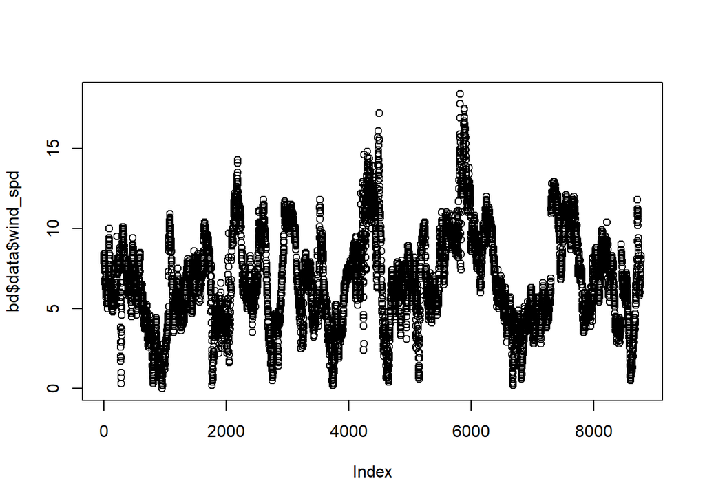

```r
plot(bd$data$wind_spd)
```

### Web Scraping

[Look here!](https://nceas.github.io/oss-lessons/data-liberation/intro-webscraping.html)

Low-level packages: `Rcurl`, `httr` for basic requests (get, give)

More user-friendly packages: `rvest`, `rselenium` (clicking buttons!!)

Request to server, response from client - language

HTML - blocks/tags in a hierarcy

CSS - formatting HTML when it’s rendered.

Selector-gadget…

```r
library("rvest")
URL <- "http://santabarbaraca.com/explore-and-discover-santa-barbara/neighborhoods-towns/santa-barbara/the-funk-zone/"

# Read the webpage into R
webpage <- read_html(URL)

# Parse the webpage for bars
# use selector gadget to identify nodes!!!!!!!!!!!!!
bars <- html_nodes(webpage, ".neighborhoods-towns-business .neighborhoods-towns-business-title")

# Extract the name of the bar
bar_names <- html_text(bars)
```

Scrape some GIS files:

```r
url <- 'http://sero.nmfs.noaa.gov/maps_gis_data/fisheries/gom/GOM_index.html'

shps <- url %>%
  read_html %>%
  html_nodes(".dataBox a") %>%
  html_attr('href') %>%
  grep('\\.zip$', ., value = T) %>%
  paste0('http://sero.nmfs.noaa.gov', .)

shps
```

```
##  [1] "http://sero.nmfs.noaa.gov/maps_gis_data/fisheries/gom/geodata/madswan_steamboat_edges.zip"
##  [2] "http://sero.nmfs.noaa.gov/maps_gis_data/fisheries/gom/geodata/swg.zip"
##  [3] "http://sero.nmfs.noaa.gov/maps_gis_data/fisheries/gom/geodata/reef_stressed.zip"
##  [4] "http://sero.nmfs.noaa.gov/maps_gis_data/fisheries/gom/geodata/gulf_reefll_seasonal.zip"
##  [5] "http://sero.nmfs.noaa.gov/maps_gis_data/fisheries/gom/geodata/longline_buoy.zip"
##  [6] "http://sero.nmfs.noaa.gov/maps_gis_data/fisheries/gom/geodata/al_smz.zip"
##  [7] "http://sero.nmfs.noaa.gov/maps_gis_data/fisheries/gom/geodata/texas_closure.zip"
##  [8] "http://sero.nmfs.noaa.gov/maps_gis_data/fisheries/gom/geodata/swfl_seasonal.zip"
##  [9] "http://sero.nmfs.noaa.gov/maps_gis_data/fisheries/gom/geodata/tortugas_shrimp.zip"
## [10] "http://sero.nmfs.noaa.gov/maps_gis_data/fisheries/gom/geodata/gulfshrimp_bycatch.zip"
## [11] "http://sero.nmfs.noaa.gov/maps_gis_data/fisheries/gom/geodata/shrimp_crab.zip"
## [12] "http://sero.nmfs.noaa.gov/maps_gis_data/fisheries/gom/geodata/flowergardenhapc.zip"
## [13] "http://sero.nmfs.noaa.gov/maps_gis_data/fisheries/gom/geodata/middlegroundshapc.zip"
## [14] "http://sero.nmfs.noaa.gov/maps_gis_data/fisheries/gom/geodata/tortugasmr_hapc.zip"
## [15] "http://sero.nmfs.noaa.gov/maps_gis_data/fisheries/gom/geodata/pulley_ridgehapc.zip"
## [16] "http://sero.nmfs.noaa.gov/maps_gis_data/fisheries/gom/geodata/stetson_bankhapc.zip"
## [17] "http://sero.nmfs.noaa.gov/maps_gis_data/fisheries/gom/geodata/mcgrail_bankhapc.zip"
## [18] "http://sero.nmfs.noaa.gov/maps_gis_data/fisheries/gom/geodata/king_mackerel.zip"
## [19] "http://sero.nmfs.noaa.gov/maps_gis_data/fisheries/gom/geodata/spanish_mackerel_po.zip"
## [20] "http://sero.nmfs.noaa.gov/maps_gis_data/fisheries/gom/geodata/cobia_po.zip"
## [21] "http://sero.nmfs.noaa.gov/maps_gis_data/fisheries/gom/geodata/lobster_trap_gear.zip"
```

### Regular expression matching

With stringr:

```r
library(stringr)

fls <- list.files('C:/docs/oss2017_notes/lessons/', '*\\.Rmd$')
str_view_all(fls, "three")
```

[interactive chart not shown]

In regex, `[]` represents a list, so anything inside of here is matched, e.g., `[aeiou]` searches for vowels:

```r
str_detect(c('hello', 'this', 'is', 'sptwq'), '[aeiou]')
```

```
## [1]  TRUE  TRUE  TRUE FALSE
```

Digits can be searched for with `\\d` %>%

```r
str_detect(c('asdfasdf8as', 'abc'), '\\d')
```

```
## [1]  TRUE FALSE
```

```r
str_detect(c('asdfasdf8as', 'abc'), '\\D')
```

```
## [1] TRUE TRUE
```

This is tricky because it says search for non-digit characters, which both strings have. Note that the caret in the `[]` is a negation.

```r
grepl('[^0-9]', c('asdfasdf8as', 'abc'))
```

```
## [1] TRUE TRUE
```

The `?` makes the preceding expression optional.

```r
grepl('a?b', c('a', 'b'))
```

```
## [1] FALSE  TRUE
```

```r
grepl('a?b', c('ab', 'bb'))
```

```
## [1] TRUE TRUE
```

This needs to be debugged:

```r
addresses <- c("Santa Barbara, CA", "Seattle, WA", "New York, NY")
str_replace(addresses, "(\\w+), (\\w+)", "City: \\1, State: \\2")
```

```
## [1] "Santa City: Barbara, State: CA" "City: Seattle, State: WA"
## [3] "New City: York, State: NY"
```